# Getting starting with git and GitHub using RStudio

Julien Brun, NCEAS

This document is a compilation of [NCEAS](https://github.com/NCEAS/) training material on version control to create a 30-45 min crash course on getting started with version control for RStudio users. You will learn:

- how to setup git on you rmachine
- how to create repository on GitHub
- git basic workflow an manipulations using RStudio
- Collabarating using git and GitHub

## Introduction to version control concepts

Version control is a system that helps you to manage the version of your files. It will help you to never have to duplicate files using `save as` as a way to keep different versions of a file (see below). Version control help you to create a timeline of snapshots contiaing different versions of a file. Bonus you can add a short description to remember what each specific version is about.

[figure not shown]

For scientists, version control is a useful tool to help you to track changes you make to your **scripts** and enable you to share your codes with your collaborators. For example, if you break your code, git can help you to revert to an earlier working version. Anothe example could be that you want one of your collaborators to add a new feature to your code to improve your analysis? Version control can help you to do so in a smooth and organized manner, tracking who changed what in the script.

## git

[figure not shown]

This training material focuses on the code verioning system calld `Git`. Note that there are others, such as `Mercurial` or `svn` for example.

Git is a *free* and *open source* distributed *version control system*. It has many functionalities and was originally geared towards software development and production environment. In fact, Git was initially designed and developed in 2005 by Linux kernel developers (including Linus Torvalds) to track the development of the Linux kernel. Here is a [fun video](https://www.youtube.com/watch?v=4XpnKHJAok8) of Linus Torvalds touting Git to Google.

### How does it work?

Git can be enabled on a specific folder/directory on your file system to version files within that directory (including sub-directories). In git (and other version control systems) terms, this “tracked folder” is called a **repository** (which formally is a specific data structure storing versioning information).

## What git is not

- Git is not a backup per se
- Git is not good at versioning large files (there are workarounds) => not meant for data

## Setting up git on your computer

`MacOSX` and `Linux` computers all come with git presinstall, but not always directly usable. The best way to test if `git` is ready to use is at the command line:

```bash
git --version
```

```
## git version 2.17.2 (Apple Git-113)
```

It should return something like above. *If you get an error, you will have to install git**

`Windows` users will have to install a software called `git bash` before being able to use git.

### Installing git

You can download a copy of `git` here: https://git-scm.com/downloads and follow the instructions.

#### Windows

You can keep the options to default during the installation, until you reach `Configuring the terminal emulator to use with Git Bash` -> be sure `Use MinTTY` is selected. This will install both git and a set of useful command-line tools using a trimmed down Bash shell.

#### Mac OSX

Depending on the version, you might have to run few commands from the terminal. Please refer to the `README.txt` that comes with the download regarding the exact steps to follow.

### Setting up your `git` identity

Before you start using git on any computer, you will have to set your identity on your system, as every snapshot of files is associated with the user whom implemented the modifications to the file(s).

**Setup your profile:**

Your name and email:

```bash
git config --global user.name "your Full Name"
git config --global user.email "your Email"
```

**Optional:**

Check that everything is correct:

```bash
git config --global --list
```

Modify everything at the same time:

```bash
git config --global --edit
```

Set your text editor:

```bash
git config --system core.editor vim
```

### Linking git and RStudio

In most of the cases, RStudio should autmatically detect `git` when it is installed on your computer. The best way to check this is to go to the `Tools` menu `-> Global Option`s and click on `git/SVN`

If `git` is properly setup, the window should look like this:

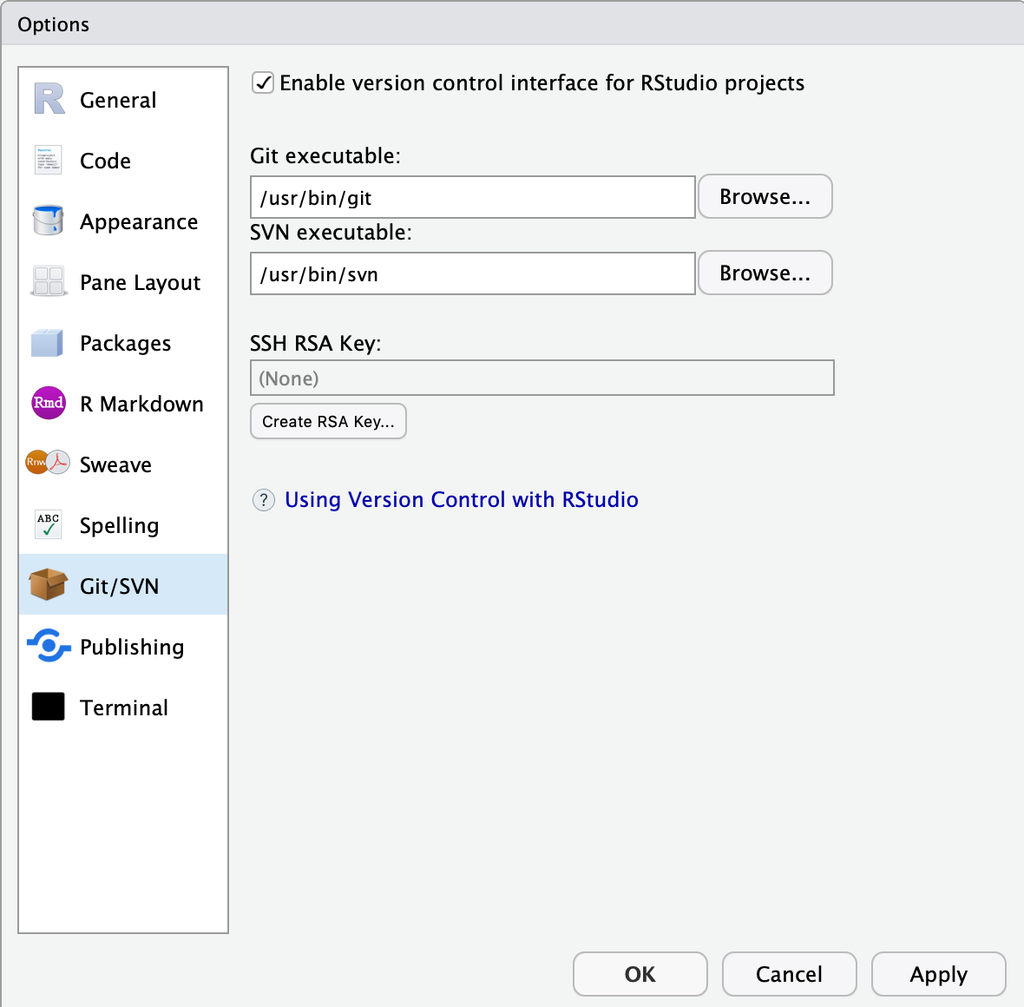

Click `OK`.

*Note:* if `git` was not enabled you might be asked to restart RStudio to enable it.

## First Repository

Git can be enabled on a specific folder/directory on your file system to version files within that directory (including sub-directories). In git (and other version control systems) terms, this “tracked folder” is called a **repository** (which formally is a specific data structure storing versioning information).

Although there many ways to start a new repository, [GitHub](https://github.com/) (or any other could solutions, such as [GitLab](https://about.gitlab.com/)) provide among the most convenient way of starting a repository.

[figure not shown]

### GitHub

**GitHub is a company that hosts git repositories online** and provides several collaboration features (among which `forking`). GitHub fosters a great user community and has built a nice web interface to git, also adding great visualization/rendering capacities of your data.

- **GitHub.com**: https://github.com
- **A user account**: https://github.com/brunj7
- **An organization account**: https://github.com/nceas
- **NCEAS GitHub instance**: https://github.nceas.ucsb.edu/

### Creating a Repository on GitHub

Here is a website to look for more pre-written`.gitignore` files: https://github.com/github/gitignore

**=> Here it is, you now have a repository in the cloud!!**

[figure not shown]

### Cloning a Repository using RStudio Projects

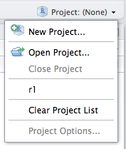

The next step is going to **get a local copy of this repository to your personal computer.**

## `git` basic workflow

### Overview

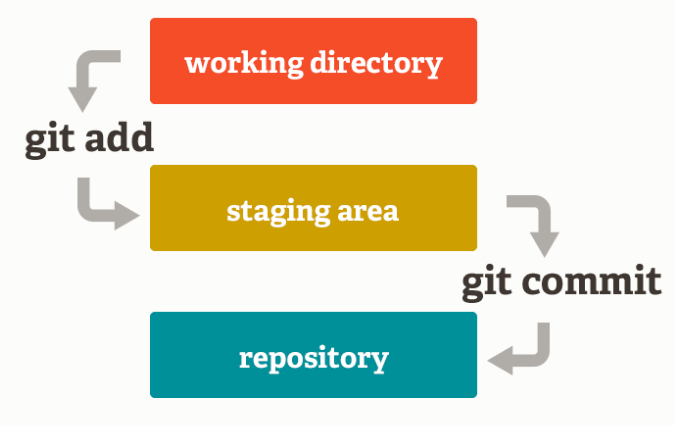

1. You modify files in your working directory and save them as usual
2. You **add** snapshots of your changes files to your staging area
3. You do a **commit**, which takes the files as they are in the staging area and permanently stores them as snapshots to your Git directory.

**And repeat!!**

Every time you create a new snapshot, you add the new version of the file to the database, while keeping all the previous versions in the database. It creates an history that is like a graph that you can navigate:

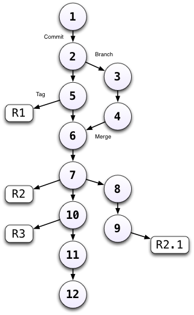